# Evaluation of the factors affecting residential solar adoption across 10 states in the United States

Brian Mulu Mutua, Dili Li

2024-04-16

# Introduction

## Background

According to the United States Energy Information Administration (EIA), the United States recorded approximately 4.07 trillion kWh in total electricity consumption in 2022 (U.S. Energy Information Administration, 2023b). The EIA further highlights that the electric power sector accounted for approximately 31% of U.S. energy-related CO2 emissions in 2022 (U.S. Energy Information Administration, 2023a). Since residential energy consumption in the United States accounts for approximately 21% of total U.S. energy consumption, according to the United States Department of Energy, CO2 emissions from the residential sector contribute to a significant proportion of the total US energy-related CO2 emissions (U.S. Department of Energy, n.d.). Additionally, data from the University of Michigan Center for Sustainable Systems highlights that despite climate-specific and resource-efficient house design strategies, per capita material use and energy consumption in the residential sector continue to increase (Center for Sustainable Systems, University of Michigan, 2023). This increase in energy consumption highlights a barrier to the US meeting its goal of 100% carbon pollution-free electricity by 2035 (U.S. Department of Energy, 2023).

## Significance

A study on the lifecycle carbon implications of residential solar-plus-storage testing in the case of California demonstrated that residential solar PV systems in 2020 had “the potential to significantly reduce both lifecycle greenhouse gas (GHG) emissions and utility costs of households” based on time of use rates and net metering policy (Zheng et al., 2021). As highlighted by Shimada and Honda (2022), residential solar photovoltaic systems have several advantages over other non-residential systems in accelerating energy sector decarbonization, including not requiring new land acquisition, minimizing interconnection work, and enhancing household satisfaction from consuming clean energy (Shimada & Honda, 2022). Hence, our subsequent statistical analysis of the factors influencing the adoption of these systems can generate insights to help guide the design of effective policy to facilitate the deployment of more residential installations in support of the energy transition.

## Research Question

**1. Are residential solar adoption rates in the United States higher in states with higher CO2 emissions per capita, average energy prices, and residential electricity demand per capita?**

## Null and Alternative Hypothesis:

In our analysis of residential solar adoption rates as measured by total state installed capacity per capita, we hypothesize that states with a higher CO2 emissions per capita, higher average energy prices, and higher residential electricity demand per capita have higher residential solar adoption rates. We can therefore formulate our null and alternative hypotheses as follows:

> Null Hypothesis (H0): There is no change in residential solar adoption rates with an increase in emissions per capita, average energy prices, and residential electricity demand per capita.

> Alternative Hypothesis (Ha): There is an increase in residential solar adoption rates with an increase in emissions per capita, average energy prices, and residential electricity demand per capita.

# Methodology

To conduct our analysis, we aggregated datasets from the U.S. Energy Information Administration (EIA) including capacity estimates from small-scale solar installations by state and sector, per capita energy-related carbon dioxide emissions by state, and monthly sales to ultimate customers be state and sector as summarized in the table below. The EIA defines small-scale solar installations as PV solar systems that are less than 1 megawatt in size, and publishes capacity estimates (in AC) as part of the Monthly Electric Power Industry Report (Form EIA-861M). We downloaded this data which is provided in Excel format for each year for the period 2014 - 2022 from the EIA website (https://www.eia.gov/electricity/data/eia861m/).

We collected data on residential energy consumption and customer counts, and electricity prices from the Annual Electric Power Industry Report (Form EIA-861) downloaded from the EIA website (https://www.eia.gov/electricity/data/state/). The current dataset, collected for the period 2010 to 2022, includes residential electricity sales by state and year in Megawatthours, count of customers by state and average electricity prices in Cents/kWh by state.

Finally, we collected per capita energy-related CO_2_ emissions data from the State Energy Data System (SEDS) environmental summary provided by the EIA for the period from 1970 to 2021 downloaded from the EIA website (https://www.eia.gov/environment/emissions/state/). The EIA defines energy-related CO_2_ emissions as the emissions released at the location where fossil fuels are consumed and publishes the data on a per capita basis.

Since the EIA only began publishing state-level estimates of small-scale solar installations by state and sector in December 2015, capacity estimates for residential solar installations are only available from 2014 to 2023. Additionally, data on per capita energy-related CO_2_ emissions is only available for the period ending 2021. To account for the data gaps, we limited the scope of our analysis to the period 2014 to 2021.

Dataset Information for the Sample Period 2014 - 2021

| Dataset | Source | Variables |
| --- | --- | --- |
| Small-scale solar installations by state and sector | EIA Form EIA-861M | Residential Solar PV Capacity (MW) by State and Year |
| Residential energy consumption and customer counts, and electricity prices | EIA Form EIA-861 | Annual Residential Electricity Consumption, Number of Consumers and Average Electricity Prices by State and Year |
| Per capita energy-related CO2 emissions | State Energy Data System (SEDS) | Per capita energy-related CO2 emissions by State and Year |

## Data Wrangling and Analysis

To facilitate our analysis, we undertook further data wrangling to consolidate the three datasets which were downloaded as separate files. We estimated residential energy installations per capita by dividing the total residential installed capacity by state and year in Megawatts by the count of customers in the state. Similarly, we estimated residential energy consumption per capita by dividing the total residential electricity sales by state and year in Megawatthours by the count of customers in the state. Since the installed capacity of residential solar systems is typically in the Kilowatt range, we converted the values for installations per capita to Kilowatthours for ease of interpretation and also centered the electricity prices around the mean. We narrowed our analysis to the top ten states with the highest installed capacity by filtering our data frame for these states namely: California, New York, New Jersey, Texas, Arizona, Massachusetts, Florida, Maryland, Illinois, and Colorado. The details of the code used in the data wrangling is provided in Section 1 of the Appendix. Further to the data wrangling, we identified our dependent variable as *Residential Solar Installations per Capita by State* and our independent variables as *Average Electricity Prices by State*, *Residential Energy Consumption State per Capita by State*, and *Per capita energy-related CO2 emissions by State* as summarized in the table below.

To account for the variations between the states, we used reference cell coding to code categorical variables for each state that we used in our model, selecting California as the reference value since it is the state with the largest reported residential solar capacity. Since our dependent variable is continuous as noted below, we selected to analyze our data using a linear regression model, testing the subsequent models with different covariates to determine which resulted in the best predictive performance. We used qqplots to test our assumptions about the normality of the data. We selected our final model variables using AIC in a stepwise algorithm and measured the predictive performance of different models by comparing the Root Mean Squared Error (RMSE) of the different models.

Model Variables

| Dependent | Independent |
| --- | --- |
| Residential Solar Installations per Capita by State (continuous variable) | Average Electricity Prices by State (continuous variable) |
| Residential Solar Installations per Capita by State (continuous variable) | Residential Energy Consumption State per Capita by State (continuous variable) |
| Residential Solar Installations per Capita by State (continuous variable) | Per capita energy-related CO2 emissions by State (continuous variable) |

## Exploratory Plots

We began our analysis by data exploration and created exploratory plots of the relationship between average electricity prices in cents/kWh, per capita CO2 emissions in metric tons, and annual electricity consumption per capita with installations per capita as shown below. Based on the plots, there appear to be a higher quantity of installations per capita in states with higher average electricity prices. Additionally, there appear to be a lower quantity of installations per capita in states with higher per capita CO2 emissions in metric tons and higher annual electricity consumption per capita.

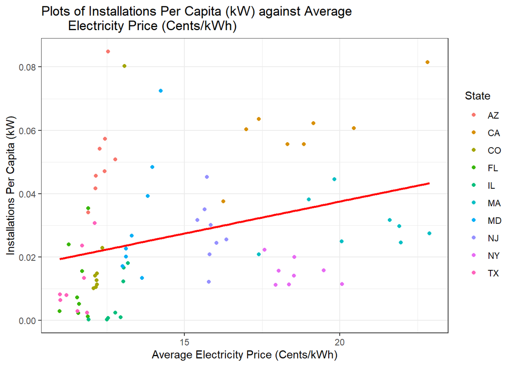

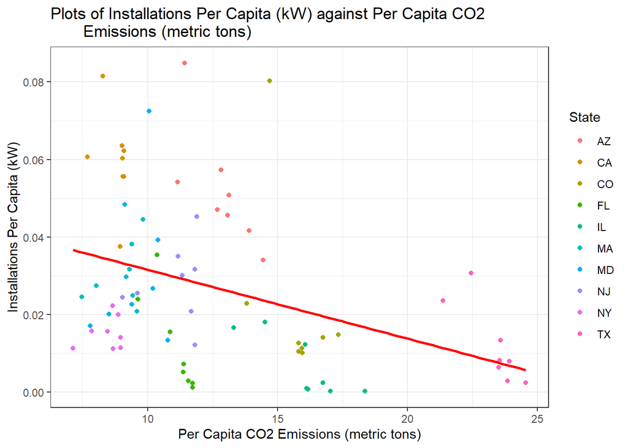

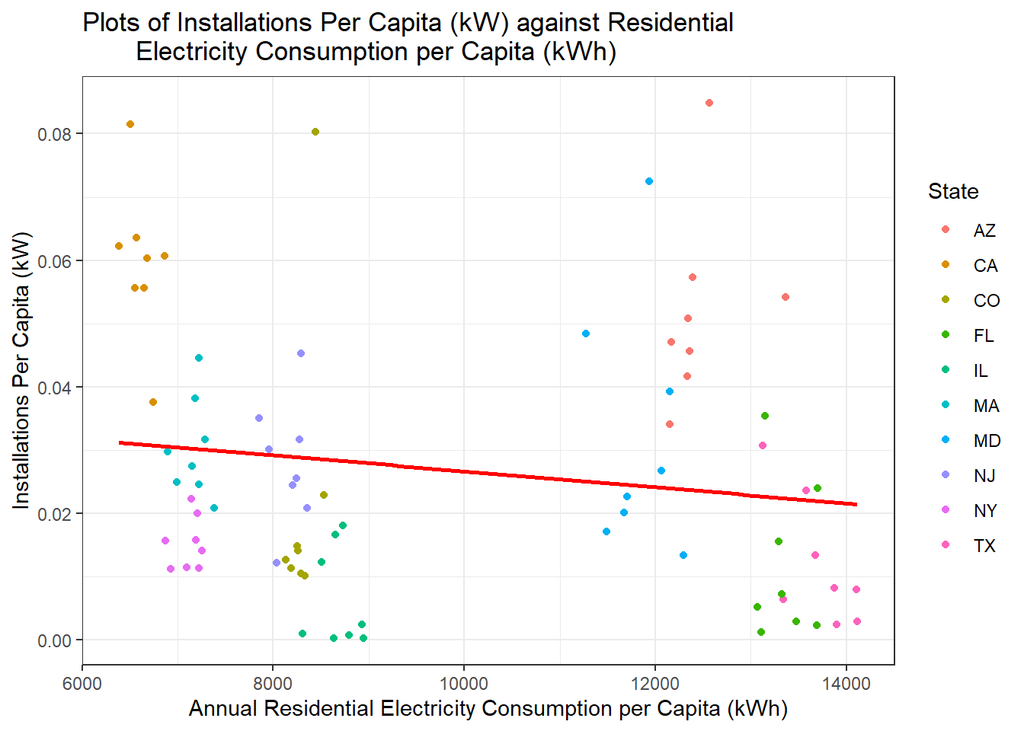

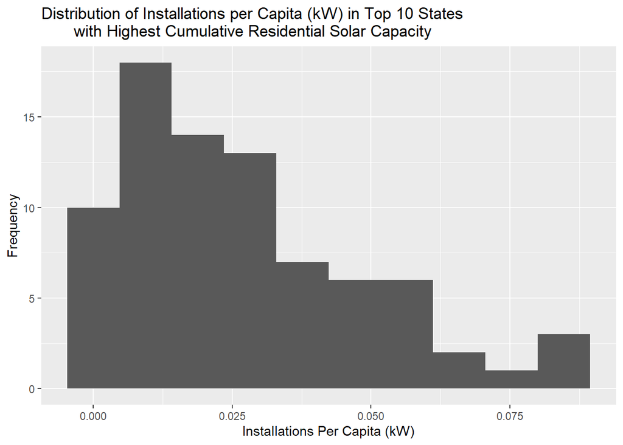

Exploratory Plots

We also computed the descriptive statistics for our dependent variable, installations per capita, in the 10 states as summarized in the table below. The total number of observations used in our analysis are 80 with a minimum value of 1.9844424^{-4}, maximum value of 0.0848873 and mean value of 0.0269722. To further analyze the relationship between the covariates and the dependent variable, we formulated a linear regression as outlined in the next section.

Descriptive statistics of the dependent variable, installations per capita

| Observations | Mean | Median | Range | Variance | StandardDeviation |
| --- | --- | --- | --- | --- | --- |
| 80 | 0.0269722 | 0.0224468 | 0.0846888 | 0.000444 | 0.0210717 |

## Linear Regression

For our analysis, we shall compared several iterations of models with different combinations of covariates to analyze the relationship between the selected covariates and cumulative solar installations per capita in the 10 states.

| **Characteristic** | **Linear Regression Model with Price, Consumption, Emissions and State** **Beta** **(95% CI)**<sup>1</sup> | **Linear Regression Model with Price, Consumption, Emissions and State** **p-value** | **Linear Regression Model with Price, Consumption and State** **Beta** **(95% CI)**<sup>1</sup> | **Linear Regression Model with Price, Consumption and State** **p-value** | **Linear Regression Model with Price, Emissions and State** **Beta** **(95% CI)**<sup>1</sup> | **Linear Regression Model with Price, Emissions and State** **p-value** |
| --- | --- | --- | --- | --- | --- | --- |
| Average Electricity Price (Cents/kWh) | 0.04 (0.03 to 0.06) | <0.001 | 0.05 (0.04 to 0.07) | <0.001 | 0.04 (0.03 to 0.06) | <0.001 |
| Residential Energy Consumption per Capita (Mwh) | 0.00 (0.00 to 0.00) | 0.90 | 0.00 (0.00 to 0.00) | 0.94 |  |  |
| Per Capita CO2 emissions (metric tons) | -0.04 (-0.05 to -0.03) | <0.001 |  |  | -0.04 (-0.05 to -0.03) | <0.001 |
| Texas | 0.63 (0.21 to 1.0) | 0.004 | 0.10 (-0.36 to 0.57) | 0.66 | 0.61 (0.40 to 0.81) | <0.001 |
| Florida | 0.11 (-0.25 to 0.47) | 0.54 | 0.10 (-0.35 to 0.54) | 0.67 | 0.09 (-0.02 to 0.20) | 0.11 |
| Arizona | 0.41 (0.09 to 0.72) | 0.012 | 0.31 (-0.08 to 0.70) | 0.12 | 0.39 (0.28 to 0.50) | <0.001 |
| New York | -0.25 (-0.31 to -0.19) | <0.001 | -0.24 (-0.31 to -0.16) | <0.001 | -0.26 (-0.31 to -0.20) | <0.001 |
| New Jersey | 0.06 (-0.05 to 0.16) | 0.26 | 0.00 (-0.13 to 0.12) | 0.98 | 0.05 (-0.02 to 0.12) | 0.13 |
| Maryland | -0.22 (-0.29 to -0.15) | <0.001 | -0.25 (-0.34 to -0.17) | <0.001 | -0.22 (-0.28 to -0.16) | <0.001 |
| Illinois | 0.23 (0.08 to 0.39) | 0.005 | 0.00 (-0.17 to 0.18) | 0.97 | 0.23 (0.11 to 0.35) | <0.001 |
| Colorado | 0.33 (0.18 to 0.48) | <0.001 | 0.12 (-0.04 to 0.28) | 0.15 | 0.33 (0.20 to 0.45) | <0.001 |
| Maryland | 0.11 (-0.17 to 0.39) | 0.43 | 0.14 (-0.21 to 0.48) | 0.43 | 0.09 (0.01 to 0.18) | 0.037 |
| R² | 0.854 |  | 0.773 |  | 0.854 |  |
| AIC | -224 |  | -191 |  | -226 |  |
| σ | 0.055 |  | 0.068 |  | 0.054 |  |

<sup>1</sup> CI = Confidence Interval

| **Characteristic** | **Linear Regression with Price, Consumption, Emissions and State and Log Transformation of Installed Capacity** **Beta** **(95% CI)**<sup>1</sup> | **Linear Regression with Price, Consumption, Emissions and State and Log Transformation of Installed Capacity** **p-value** | **Linear Regression with Price, Consumption and State and Log Transformation of Installed Capacity** **Beta** **(95% CI)**<sup>1</sup> | **Linear Regression with Price, Consumption and State and Log Transformation of Installed Capacity** **p-value** | **Linear Regression with Price, Emissions and State and Log Transformation of Installed Capacity** **Beta** **(95% CI)**<sup>1</sup> | **Linear Regression with Price, Emissions and State and Log Transformation of Installed Capacity** **p-value** |
| --- | --- | --- | --- | --- | --- | --- |
| Average Electricity Price (Cents/kWh) | 0.10 (-0.04 to 0.25) | 0.15 | 0.28 (0.08 to 0.48) | 0.008 | 0.12 (-0.03 to 0.27) | 0.11 |
| Residential Energy Consumption per Capita (Mwh) | 0.00 (0.00 to 0.00) | 0.021 | 0.00 (0.00 to 0.00) | 0.12 |  |  |
| Per Capita CO2 emissions (metric tons) | -0.61 (-0.75 to -0.47) | <0.001 |  |  | -0.61 (-0.75 to -0.46) | <0.001 |
| Texas | 12 (7.4 to 16) | <0.001 | 4.0 (-1.6 to 9.7) | 0.16 | 7.3 (5.2 to 9.5) | <0.001 |
| Florida | 3.7 (-0.02 to 7.4) | 0.051 | 3.5 (-1.9 to 8.8) | 0.21 | -0.48 (-1.7 to 0.70) | 0.42 |
| Arizona | 6.7 (3.5 to 10) | <0.001 | 5.3 (0.60 to 10) | 0.028 | 3.1 (2.0 to 4.2) | <0.001 |
| New York | -1.2 (-1.8 to -0.61) | <0.001 | -1.0 (-1.9 to -0.10) | 0.030 | -1.5 (-2.1 to -0.96) | <0.001 |
| New Jersey | 2.0 (0.93 to 3.1) | <0.001 | 1.1 (-0.41 to 2.6) | 0.15 | 1.1 (0.33 to 1.8) | 0.005 |
| Maryland | -0.35 (-1.1 to 0.34) | 0.32 | -0.83 (-1.8 to 0.17) | 0.10 | -0.73 (-1.4 to -0.09) | 0.026 |
| Illinois | 2.4 (0.76 to 4.0) | 0.005 | -1.0 (-3.1 to 1.1) | 0.34 | 1.2 (-0.14 to 2.5) | 0.078 |
| Colorado | 4.9 (3.3 to 6.4) | <0.001 | 1.7 (-0.24 to 3.6) | 0.084 | 3.9 (2.6 to 5.2) | <0.001 |
| Maryland | 3.6 (0.73 to 6.5) | 0.015 | 4.0 (-0.19 to 8.2) | 0.061 | 0.39 (-0.56 to 1.3) | 0.42 |
| R² | 0.876 |  | 0.735 |  | 0.866 |  |
| AIC | 148 |  | 207 |  | 153 |  |
| σ | 0.560 |  | 0.814 |  | 0.579 |  |

<sup>1</sup> CI = Confidence Interval

#Result To explore the potential impacts on the residential solar adoption rates, we use the cumulative installation per capita (calculated by installation divided by population) as our dependent variable. And we select the price, emissions per capita, consumption per capita and states as the independent variables.

In the model1 series, we explored the impacts from price on installation per capita. We tried the models with classic linear model and log-transformed Cumulative installation per capita. We found that log-transformed Cumulative installation per capita could make the QQ-plot have the lower variance and make the confidence level of variables (like price) higher.

In the model4 series, we explored the impacts of different states. We centered the price data to remove the impacts of price changes year by year. And compare the impacts of emissions per capita and consumption per capita to this model. As a result, emissions per capita is the better indicators with the higher significance level.

Our results correlates with our null hypothesis partly, emissions per capita and different states are the main factors to affect the residential solar adoption rates, and the emissions per capita have negative coefficient with Cumulative installlation per capita, which means the states will higher emissions per capita generally have lower residential solar adoption rates.

The limitations of our study is we only focus on the linear model.The relationship between our dependent variables and independent variables might be not linear relationship, there might be other models to better fit in with our data. Also, the independent variables we selected might have some correlations like consumption per capita and emissions per capita. It caused the scope of inferences in our model not perform well.

To compare model fits, we used Root Mean Squared Prediction Error (RMSPE) as demonstrated below.

```
## [1] 0.1506931
## [1] 0.1322104
## [1] 0.1564707
## [1] 0.1821643
```

# Appendix A: Regression Models evaluated in the analysis

## Regression Models

```r
fit1 <- lm(CumulativeInstallationsPerCapita ~  Price, data = df_capacitydemandemissions)
summary(fit1)
#plot(fit1)

fit1.1 <- glm(CumulativeInstallationsPerCapita ~  Price,
             family = "poisson",
             data = df_capacitydemandemissions)
summary(fit1.1)
#plot(fit1.1)

fit1.2 <- lm(log(CumulativeInstallationsPerCapita) ~  Price,
             data = df_capacitydemandemissions)
summary(fit1.2)
#plot(fit1.2)

#Creating summary tables
fit1.t0 <- tbl_regression(fit1,
                        label = list(Price ~ "Average Electricity Prcice")) %>%
  bold_p() %>%
  add_glance_table(
    label = list(sigma ~ "\U03C3"),
    include = c(r.squared, AIC, sigma)
  )

fit1.t1 <- tbl_regression(fit1.1,
                        label = list(Price ~ "Average Electricity Prcice")) %>%
  bold_p()

fit1.t2 <- tbl_regression(fit1.2,
                        label = list(Price ~ "Average Electricity Prcice")) %>%
  bold_p() %>%
  add_glance_table(
    label = list(sigma ~ "\U03C3"),
    include = c(r.squared, AIC, sigma)
  )


tbl_merge_fit1 <-
  tbl_merge(
    tbls = list(fit1.t1, fit1.t0, fit1.t2),
    tab_spanner = c("**Poisson Regression**",
                    "**Linear Regression**",
                    "**Linear Regression with Log Transformation of Installed Capacity**")
  )

tbl_merge_fit1
```

```
##
## Call:
## lm(formula = CumulativeInstallationsPerCapita ~ Price, data = df_capacitydemandemissions)
##
## Residuals:
##      Min       1Q   Median       3Q      Max
## -0.21179 -0.08313 -0.03427  0.06290  0.38966
##
## Coefficients:
##              Estimate Std. Error t value Pr(>|t|)
## (Intercept) -0.103318   0.060238  -1.715   0.0903 .
## Price        0.016857   0.003977   4.239 6.12e-05 ***
## ---
## Signif. codes:  0 '***' 0.001 '**' 0.01 '*' 0.05 '.' 0.1 ' ' 1
##
## Residual standard error: 0.1192 on 78 degrees of freedom
## Multiple R-squared:  0.1872, Adjusted R-squared:  0.1768
## F-statistic: 17.97 on 1 and 78 DF,  p-value: 6.117e-05
##
##
## Call:
## glm(formula = CumulativeInstallationsPerCapita ~ Price, family = "poisson",
##     data = df_capacitydemandemissions)
##
## Coefficients:
##             Estimate Std. Error z value Pr(>|z|)
## (Intercept) -3.51018    1.30314  -2.694  0.00707 **
## Price        0.10286    0.07902   1.302  0.19303
## ---
## Signif. codes:  0 '***' 0.001 '**' 0.01 '*' 0.05 '.' 0.1 ' ' 1
##
## (Dispersion parameter for poisson family taken to be 1)
##
##     Null deviance: 9.1952  on 79  degrees of freedom
## Residual deviance: 7.5863  on 78  degrees of freedom
## AIC: Inf
##
## Number of Fisher Scoring iterations: 5
##
##
## Call:
## lm(formula = log(CumulativeInstallationsPerCapita) ~ Price, data = df_capacitydemandemissions)
##
## Residuals:
##     Min      1Q  Median      3Q     Max
## -4.1475 -0.5631  0.1100  0.8802  2.3032
##
## Coefficients:
##             Estimate Std. Error t value Pr(>|t|)
## (Intercept) -5.40151    0.66984  -8.064 7.08e-12 ***
## Price        0.19143    0.04422   4.329 4.41e-05 ***
## ---
## Signif. codes:  0 '***' 0.001 '**' 0.01 '*' 0.05 '.' 0.1 ' ' 1
##
## Residual standard error: 1.325 on 78 degrees of freedom
## Multiple R-squared:  0.1937, Adjusted R-squared:  0.1834
## F-statistic: 18.74 on 1 and 78 DF,  p-value: 4.408e-05
```

| **Characteristic** | **Poisson Regression** **log(IRR)** **(95% CI)**<sup>1</sup> | **Poisson Regression** **p-value** | **Linear Regression** **Beta** **(95% CI)**<sup>1</sup> | **Linear Regression** **p-value** | **Linear Regression with Log Transformation of Installed Capacity** **Beta** **(95% CI)**<sup>1</sup> | **Linear Regression with Log Transformation of Installed Capacity** **p-value** |
| --- | --- | --- | --- | --- | --- | --- |
| Average Electricity Prcice | 0.10 (-0.06 to 0.26) | 0.19 | 0.02 (0.01 to 0.02) | <0.001 | 0.19 (0.10 to 0.28) | <0.001 |
| R² |  |  | 0.187 |  | 0.194 |  |
| AIC |  |  | -109 |  | 276 |  |
| σ |  |  | 0.119 |  | 1.33 |  |

<sup>1</sup> IRR = Incidence Rate Ratio, CI = Confidence Interval, CI = Confidence Interval

```r
fit2 <- lm(CumulativeInstallations ~  Price + ConsumptionPerCapita, data = df_capacitydemandemissions)
summary(fit2)
#plot(fit2)

fit2.1 <- glm(CumulativeInstallations ~  Price + ConsumptionPerCapita,
              family = "poisson",
              data = df_capacitydemandemissions)
summary(fit2.1)
#plot(fit2.1)

fit2.2 <- lm(log(CumulativeInstallations) ~  Price + ConsumptionPerCapita, data = df_capacitydemandemissions)
summary(fit2.2)
#plot(fit2.2)
```

```
##
## Call:
## lm(formula = CumulativeInstallations ~ Price + ConsumptionPerCapita,
##     data = df_capacitydemandemissions)
##
## Residuals:
##     Min      1Q  Median      3Q     Max
## -1827.1  -588.2  -144.4   115.8  5397.1
##
## Coefficients:
##                        Estimate Std. Error t value Pr(>|t|)
## (Intercept)          -2.805e+03  1.695e+03  -1.654  0.10214
## Price                 2.269e+02  6.645e+01   3.414  0.00102 **
## ConsumptionPerCapita  3.419e-02  8.405e-02   0.407  0.68528
## ---
## Signif. codes:  0 '***' 0.001 '**' 0.01 '*' 0.05 '.' 0.1 ' ' 1
##
## Residual standard error: 1295 on 77 degrees of freedom
## Multiple R-squared:  0.2296, Adjusted R-squared:  0.2096
## F-statistic: 11.47 on 2 and 77 DF,  p-value: 4.358e-05
##
##
## Call:
## glm(formula = CumulativeInstallations ~ Price + ConsumptionPerCapita,
##     family = "poisson", data = df_capacitydemandemissions)
##
## Coefficients:
##                        Estimate Std. Error z value Pr(>|z|)
## (Intercept)           4.156e+00  4.738e-02   87.71   <2e-16 ***
## Price                 1.823e-01  1.595e-03  114.30   <2e-16 ***
## ConsumptionPerCapita -3.374e-05  2.711e-06  -12.45   <2e-16 ***
## ---
## Signif. codes:  0 '***' 0.001 '**' 0.01 '*' 0.05 '.' 0.1 ' ' 1
##
## (Dispersion parameter for poisson family taken to be 1)
##
##     Null deviance: 108218  on 79  degrees of freedom
## Residual deviance:  70095  on 77  degrees of freedom
## AIC: Inf
##
## Number of Fisher Scoring iterations: 5
##
##
## Call:
## lm(formula = log(CumulativeInstallations) ~ Price + ConsumptionPerCapita,
##     data = df_capacitydemandemissions)
##
## Residuals:
##     Min      1Q  Median      3Q     Max
## -3.6135 -0.8841  0.2612  0.8033  1.9935
##
## Coefficients:
##                        Estimate Std. Error t value Pr(>|t|)
## (Intercept)          -4.036e-01  1.641e+00  -0.246   0.8063
## Price                 3.103e-01  6.430e-02   4.826  6.9e-06 ***
## ConsumptionPerCapita  1.787e-04  8.134e-05   2.197   0.0311 *
## ---
## Signif. codes:  0 '***' 0.001 '**' 0.01 '*' 0.05 '.' 0.1 ' ' 1
##
## Residual standard error: 1.253 on 77 degrees of freedom
## Multiple R-squared:  0.2694, Adjusted R-squared:  0.2504
## F-statistic: 14.19 on 2 and 77 DF,  p-value: 5.657e-06
```

```r
fit3.1 <- glm(CumulativeInstallationsPerCapita ~  Price + ConsumptionPerCapita + Emissions,
             family = "poisson",
           data = df_capacitydemandemissions)
summary(fit3.1)
#plot(fit3.1)

fit3.2 <- lm(CumulativeInstallationsPerCapita ~  Price + ConsumptionPerCapita + Emissions,
           data = df_capacitydemandemissions)
summary(fit3.2)
#plot(fit3.2)
```

```
##
## Call:
## glm(formula = CumulativeInstallationsPerCapita ~ Price + ConsumptionPerCapita +
##     Emissions, family = "poisson", data = df_capacitydemandemissions)
##
## Coefficients:
##                        Estimate Std. Error z value Pr(>|z|)
## (Intercept)          -2.749e+00  4.834e+00  -0.569    0.570
## Price                 8.096e-02  1.625e-01   0.498    0.618
## ConsumptionPerCapita  8.193e-05  2.015e-04   0.407    0.684
## Emissions            -1.041e-01  1.166e-01  -0.893    0.372
##
## (Dispersion parameter for poisson family taken to be 1)
##
##     Null deviance: 9.1952  on 79  degrees of freedom
## Residual deviance: 6.4046  on 76  degrees of freedom
## AIC: Inf
##
## Number of Fisher Scoring iterations: 5
##
##
## Call:
## lm(formula = CumulativeInstallationsPerCapita ~ Price + ConsumptionPerCapita +
##     Emissions, data = df_capacitydemandemissions)
##
## Residuals:
##      Min       1Q   Median       3Q      Max
## -0.20963 -0.08050 -0.01865  0.05682  0.34229
##
## Coefficients:
##                        Estimate Std. Error t value Pr(>|t|)
## (Intercept)          -1.060e-01  1.767e-01  -0.600   0.5502
## Price                 1.650e-02  6.681e-03   2.470   0.0157 *
## ConsumptionPerCapita  1.268e-05  7.396e-06   1.715   0.0905 .
## Emissions            -9.178e-03  3.674e-03  -2.498   0.0147 *
## ---
## Signif. codes:  0 '***' 0.001 '**' 0.01 '*' 0.05 '.' 0.1 ' ' 1
##
## Residual standard error: 0.114 on 76 degrees of freedom
## Multiple R-squared:  0.2755, Adjusted R-squared:  0.2469
## F-statistic: 9.634 on 3 and 76 DF,  p-value: 1.826e-05
```

```r
#Fitting HierachicalModel
mixedModel1 <- lmer(InstallationsPerCapita ~  Price.Centered + ConsumptionPerCapita + Emissions + (1|State) + (1|Year),
            data = df_capacitydemandemissions)
summary(mixedModel1)
mixedModel1@u
```

```
## Linear mixed model fit by REML ['lmerMod']
## Formula: InstallationsPerCapita ~ Price.Centered + ConsumptionPerCapita +
##     Emissions + (1 | State) + (1 | Year)
##    Data: df_capacitydemandemissions
##
## REML criterion at convergence: -395.8
##
## Scaled residuals:
##     Min      1Q  Median      3Q     Max
## -1.6970 -0.5383 -0.1621  0.4365  4.0515
##
## Random effects:
##  Groups   Name        Variance  Std.Dev.
##  State    (Intercept) 2.991e-04 0.017294
##  Year     (Intercept) 2.446e-05 0.004945
##  Residual             1.384e-04 0.011765
## Number of obs: 80, groups:  State, 10; Year, 8
##
## Fixed effects:
##                        Estimate Std. Error t value
## (Intercept)           2.436e-02  2.570e-02   0.948
## Price.Centered        2.428e-03  1.423e-03   1.706
## ConsumptionPerCapita  2.547e-06  2.447e-06   1.041
## Emissions            -1.762e-03  1.236e-03  -1.426
##
## Correlation of Fixed Effects:
##             (Intr) Prc.Cn CnsmPC
## Price.Cntrd -0.550
## CnsmptnPrCp -0.777  0.423
## Emissions   -0.375  0.261 -0.248
## fit warnings:
## Some predictor variables are on very different scales: consider rescaling
##  [1]  1.569138e-02  1.553907e-02  6.669075e-03 -1.243923e-02 -4.402203e-03
##  [6] -6.795050e-03 -1.375003e-03 -6.669196e-05 -1.388262e-02  1.061269e-03
## [11] -1.403333e-02 -1.113529e-03  8.563723e-03  6.316425e-04 -4.062866e-03
## [16] -1.811862e-03 -4.844626e-03  1.667084e-02
```